# Rプログラミング入門 R Markdownによるレポート作成

Cho（ztempest0218@gmail.com）

Last Updated: 2026-07-09

**今回の内容**

- R Markdownの仕組み：文章・コード・結果を1つのファイルにまとめる
- Markdown記法とコードチャンクの書き方
- データ可視化レポート（新聞一面トップ記事）への仕上げ方

**今回使用するデータ**

- ssdse_clean_sample_2018_2023.rds

# 1 なぜR Markdownか

R Scriptにコードを書き、結果をConsoleや図で確認するというスタイルで分析を進めてきた。しかし、分析は結果を「出す」だけでは終わらない。卒論もゼミ報告も業務レポートも、最終成果物は、結果を人に**「伝える」**文書である。せっかくの分析も、分かりやすい形に整理して伝えなければ相手には見えず、これまでの作業がすべて無駄になってしまう。

従来のやり方は、図は `ggsave()` で保存してWordに貼り付け、平均値や回帰係数はConsoleからコピーして本文に貼り付ける（出力を表に整形し直すのは手間であり、うまく整形できずに**スクリーンショットをそのまま貼る学生も多いが、これはレポート・論文の作法として認められていない**）。このやり方は、**分析をやり直すたびに破綻する**。データの更新、外れ値の除外、変数の追加のたびに、すべての図と数値を1つずつ貼り替えることになり、1箇所でも貼り忘れると、本文の数字と図が食い違う「事故」が起きる。このようなコピペミスは、査読を通った学術論文でもしばしば発見されている。

学んだDRY原則の通り、**分析結果を手作業でコピペするべきではない**。この問題を解決するのが**R Markdown**である。**文章とRコードを1つのファイル（拡張子 `.Rmd`）に書き**、ボタン1つ（**Knit**）でコードをすべて実行し、その結果（図・表・数値）が埋め込まれた完成文書（HTML・Word・PDF）を自動生成する。

[figure not shown]

この仕組みの利点は、**再現可能性**（reproducibility）にある。データや分析が変わっても、Knitし直すだけで、すべての図・表・数値が最新の結果に更新され、貼り忘れも写し間違いも原理的に起こりえない。R Markdownは「R Scriptは再現可能な処理の記録」を、レポートまで拡張したものと言ってよい。もう1つの利点は、HTMLを直接生成できることである。作った文書は、そのままウェブページとして無理なく公開できる。

**この講義資料そのものも、毎回R Markdownで作られ、HTMLとして[授業用サイト](https://ztempest0218.github.io/R-Programming/)で公開されている**。ページ内のコードと出力がぴったり一致していたのは、Knitのたびにコードが実際に実行されていたからである。R Markdownは、学術論文、書籍（教科書 [R for Data Science](https://r4ds.hadley.nz/) もそうである）、企業の定型レポートまで、幅広く使われている。

# 2 最初のR Markdown文書

## 2.1 新規作成からKnitまで

R Markdownを使うのに必要な `rmarkdown` パッケージは、RStudioに同梱されているため、通常は追加インストール不要である（もしKnitボタンが見当たらなければ、Consoleで `install.packages("rmarkdown")` を実行する）。

手順は、次の3ステップである。

1. RStudioのメニューから **File > New File > R Markdown…** を選ぶ。タイトルと著者名を入力し、出力形式は **HTML** のまま **OK** を押す

[figure not shown]

   File > New File > R Markdown… から新規作成する

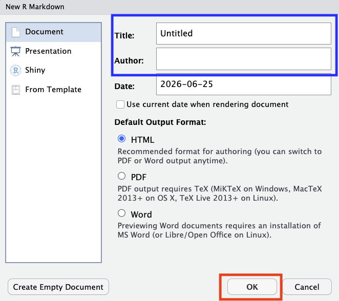

   タイトルと著者名を入力し、HTMLのまま OK を押す

2. サンプル文書が開くので、まず **`.Rmd` ファイルとして保存**する（保存場所が重要である。理由は後述）
3. エディタ上部の **Knit** ボタン（毛糸玉のアイコン）を押す。ショートカットは `Cmd + Shift + K`（Macの場合）/ `Ctrl + Shift + K`（Windowsの場合）。エディタ上部の **Knit on Save** にチェックを入れておくと、ファイルを保存するたびに自動でKnitされるので便利である

[figure not shown]

   サンプル文書。Knit on Save にチェックを入れると、保存時に自動でKnitされる

数秒待つと、コードが実行され、図と結果が埋め込まれたHTMLファイルが表示される。`.Rmd` と同じフォルダに、同じ名前の `.html` ファイルが生成されているはずである。このHTMLは**1ファイルで完結しており（画像も内部に埋め込まれている）、そのままメールやClassroomで提出できる**。

まずは自分の手で、このサンプル文書のKnitを体験してみてほしい。

## 2.2 R Markdown文書の3つの部分

生成されたサンプル文書を眺めると、`.Rmd` ファイルは3つの部分からできていることがわかる。

[figure not shown]

| 部分 | 場所 | 役割 |
| --- | --- | --- |
| YAMLヘッダー | ファイル冒頭の `---` と `---` の間 | タイトル・著者・出力形式など、文書全体の設定 |
| テキスト | ヘッダーの外側すべて | レポートの本文。**Markdown記法**で書く |
| コードチャンク | `` ```{r} `` と `` ``` `` の間 | Knit時に実行されるRコード。結果がその場に埋め込まれる |

以下、②テキスト（Markdown記法）、③コードチャンク、①YAMLヘッダーの順に見ていく。

# 3 Markdown記法

Markdownとは、**記号だけで文章の見た目（見出し・太字・箇条書きなど）を指定する記法**である。Wordのようにマウスでボタンを押す代わりに、テキストに記号を書き込む。書式調整は一切マウスで行わず、簡単な記号だけで綺麗な文書を出力できる。覚えるべき記号は少なく、主なものは次の通りである。

| 書き方 | 意味 |
| --- | --- |
| `# 見出し1`、`## 見出し2`、`### 見出し3` | 見出し（`#` の数が階層） |
| `**太字**` | **太字** |
| `*斜体*` | *斜体* |
| `- 項目` | 箇条書き |
| `1. 項目` | 番号付きリスト |
| `[表示テキスト](URL)` | リンク |
| `![説明](画像ファイル名.png)` | 画像の挿入 |
| `> 引用文` | 引用 |
| `$y = a + bx$` | 数式（第11回の回帰式のような表記） |
| `***` | 水平線 |

**例1：見出し・太字・箇条書き**

次のように書くと、

```markdown
## 分析の目的

本稿では、**保育所等の定員**と出生率の関係を分析する。使用するデータは以下の通り。

- SSDSE（教育用標準データセット）

- 期間：2018〜2023年
```

次のように表示される。

> 分析の目的

> 本稿では、**保育所等の定員**と出生率の関係を分析する。使用するデータは以下の通り。
> - SSDSE（教育用標準データセット）
> - 期間：2018〜2023年

**注意：空行を忘れずに**

1つだけ注意がある。Markdownでは、**箇条書きや見出しの前（前の段落との間）に空行が必要**である。たとえば、前の文と箇条書きの間に空行を入れずに

```markdown
使用するデータは以下の通り。
- SSDSE（教育用標準データセット）
- 期間：2018〜2023年
```

と書くと、箇条書きとして認識されず、記号ごと1つの段落につながってしまう。

> 使用するデータは以下の通り。 - SSDSE（教育用標準データセット） - 期間：2018〜2023年

「箇条書きにならない」「見出しにならない」ときは、まず直前の空行を疑うとよい。なお、項目と項目の**間**の空行は任意で、入れると行間が広めに表示される（この資料の箇条書きは、その書き方である）。

**例2：数式**

数式は `$` で囲み、LaTeXという組版システムの記法で書く。次のように書くと、

```markdown
効用関数は $U(x_1, x_2) = x_1^{\alpha} x_2^{1-\alpha}$ と書ける。
```

次のように表示される。

> 効用関数は $U(x_1, x_2) = x_1^{\alpha} x_2^{1-\alpha}$ と書ける。

数式の中身に使うLaTeX記法のうち、レポートでよく使うものを挙げておく。

| 書き方 | 表示 | 用途 |
| --- | --- | --- |
| `$x^2$` | $x^2$ | 上付き（べき乗） |
| `$\beta_0$` | $\beta_0$ | ギリシャ文字と下付き |
| `$\hat{\beta}$` | $\hat{\beta}$ | ハット（推定値） |
| `$\bar{x}$` | $\bar{x}$ | バー（平均） |
| `$\frac{a}{b}$` | $\frac{a}{b}$ | 分数 |
| `$\sum_{i=1}^{n} x_i$` | $\sum_{i=1}^{n} x_i$ | 総和 |
| `$\log(x)$`、`$\sqrt{x}$` | $\log(x)$、$\sqrt{x}$ | 対数・平方根 |

また、`$` の代わりに `$$` で囲むと、数式が独立した行に中央揃えで表示される。第11回で見た回帰式は、次のように書いたものである。

```markdown
$$
y_i = \beta_0 + \beta_1 x_i + u_i
$$
```

次のように表示される。

$$y_i = \beta_0 + \beta_1 x_i + u_i$$

**例3：画像**

画像は `![説明](ファイル名)` で挿入する。幅は `{width=70%}` のように指定できる。次のように書くと、

```markdown
![シカゴの犯罪マップ（出所：BestNeighborhood.org）](chicago-crime-map.png){width=70%}
```

次のように表示される。

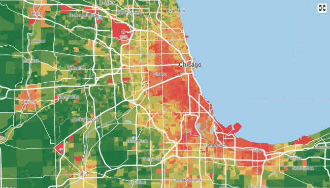

> シカゴの犯罪マップ（出所：BestNeighborhood.org）

なお、エディタ左上の **Source / Visual** ボタンで、記号を書かずにWordのような画面で編集できる**Visualモード**に切り替えられる。記号に慣れないうちはVisualモードで書き、Sourceモードでどの記号に変換されたかを確認すると、覚えが早い。

# 4 コードチャンク

## 4.1 チャンクの基本

コードチャンク（chunk）は、`` ```{r} `` で始まり `` ``` `` で終わるブロックである。この中に書いたRコードは、Knit時に**上から順にすべて実行**され、結果（出力・図・表）がその場に埋め込まれる。

````markdown
```{r}
summary(cars)
```
````

チャンクの挿入はショートカット `Cmd + Option + I`（Mac）/ `Ctrl + Alt + I`（Windows）が便利である。また、チャンク右上の**緑の実行ボタン（▶）**を押すと、Knitせずにそのチャンクだけを実行して動作確認できる。

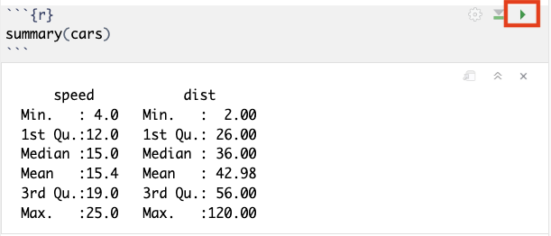

チャンクを ▶ で実行すると、結果がすぐ下に表示される

**チャンクを1つ書くたびに▶で動作確認し、区切りのよいところでKnitして全体を通す**、というのが基本的な作業リズムである。いきなり動作未確認のチャンクを大量に書くと、デバッグがかなり大変なのである。

## 4.2 チャンクオプション

チャンクは、`` ```{r} `` の波かっこ内にオプションを書くことで、**コードや結果の見せ方**を制御できる。

````markdown
```{r cars, echo = FALSE, fig.width = 6}
plot(cars)
```
````

これをKnitすると、次のように表示される。`echo = FALSE` なので、コードは表示されず、図だけが出る。

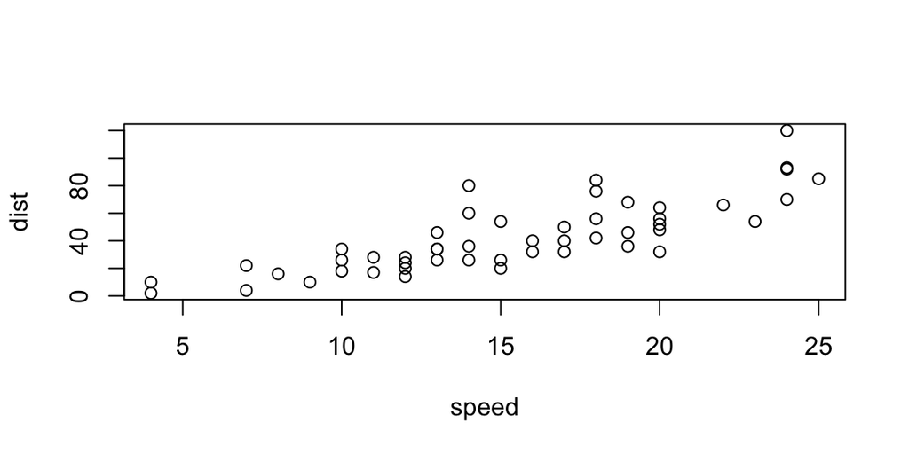

先頭の `cars` は、オプションではなく**チャンクの名前（ラベル）**である。なくても動くが、付けておくと、エラーが出たときに `Quitting from lines 17-19 [cars]` のようにチャンク名つきで場所を教えてくれるほか、生成される図のファイル名にも使われるため、デバッグが楽になる。サンプル文書の `{r cars}` や `{r pressure}` は、これである。ただし、**同じ名前を2つのチャンクに使うとエラーになる**ので注意すること。

名前の後ろに続くのがオプションである。よく使うオプションは、次の6つで足りる。

| オプション | 既定値 | 意味 |
| --- | --- | --- |
| `echo = FALSE` | TRUE | コードを隠し、**結果だけ**を表示する |
| `eval = FALSE` | TRUE | コードを実行せず、**コードだけ**を表示する |
| `include = FALSE` | TRUE | 実行はするが、コードも結果も表示しない |
| `message = FALSE`、`warning = FALSE` | TRUE | パッケージ読み込み時などのメッセージ・警告を隠す |
| `fig.width`、`fig.height` | 7、5 | 図の幅・高さ（インチ単位） |
| `fig.cap = "..."` | なし | 図にキャプション（説明文）をつける |

どれを使うかは、**読者にコードを見せるかどうか**で決まる。授業の課題のように「コードも採点対象」なら既定のまま（`echo = TRUE`）でよい。一方、新聞記事やビジネスレポートのように**読者がコードに興味がない**文書では、`echo = FALSE` で結果だけを見せるのが普通である。

## 4.3 setupチャンク

すべてのチャンクに同じオプションを毎回書くのは、DRY原則に反する。そこで、**YAMLヘッダーの直後（ファイルの最初のチャンク）にsetupチャンクを1つ置き**、`knitr::opts_chunk$set()` で既定値をまとめて設定する。チャンクは上から順に実行されるため、設定はこの位置に書いてこそ、以降のすべてのチャンクに効く。サンプル文書の冒頭にあった `{r setup, include=FALSE}` が、まさにこれである。

````markdown
```{r setup, include = FALSE}
knitr::opts_chunk$set(
  echo = TRUE,        # 以降すべてのチャンクでコードを表示する
  message = FALSE,
  warning = FALSE,
  fig.align = "center"
)

library(tidyverse)    # パッケージ読み込みもここにまとめる
```
````

setupチャンク自体は `include = FALSE` で見えなくしておく。パッケージの読み込みやデータの読み込みも、このチャンクにまとめておくと見通しがよい。実は、この講義資料の冒頭にも同じ形のsetupチャンクが置かれている。

## 4.4 インラインコード：本文に数値を埋め込む

チャンクとは別に、**本文の文章の中にRコードの結果を直接埋め込む**書き方がある。バッククォートで `` `r コード` `` のように囲む。

たとえば本文に、

```markdown
carsデータは `r nrow(cars)` 行である。速度の平均は
時速 `r round(mean(cars$speed), 1)` マイルである。
```

と書いてKnitすると、次のように表示される。

> carsデータは 50 行である。速度の平均は時速 15.4 マイルである。

この数値は手打ちではなく、**Knitのたびにデータから計算し直されている**。データが更新されても、本文の数字が古いまま残る事故は起きない。ここまでの自動化を課題で求めるわけではないが、少なくとも図表は常に最新の結果に保っておくこと。

# 5 YAMLヘッダーと出力形式

ファイル冒頭のYAMLヘッダーでは、タイトル・著者・日付と、文書全体のオプションを設定する。レポートでよく使う形は、次の通りである。

```yaml
---
title: "イラン戦争の不都合な真実"
author: "経済 太郎（学籍番号）"
date: "2026-07-25"
output:
  html_document:
    toc: true              # 目次をつける
    toc_float: true        # 目次をスクロールに追随させる
    number_sections: true  # 見出しに番号を振る
    mathjax: "https://cdnjs.cloudflare.com/ajax/libs/mathjax/2.7.5/MathJax.js?config=TeX-AMS_CHTML.js"  # 数式（LaTeX）をきれいな字体で表示する
---
```

インデント（字下げ）に意味があるため、**スペースの数まで正確に**写すこと。ルールは、**階層が1つ深くなるごとに半角スペース2つ**である（`output:` の下の `html_document:` は2つ、さらにその下のオプションは4つ）。Tabキーや全角スペースは使えず、エラーになるので、必ず半角スペースで下げること。

YAMLのより細かい設定は、必要になったときに各自で調べればよい。課題の提出では、配布する課題テンプレート（`HW7.Rmd`）をそのまま使い、**タイトル・著者・日付・出力形式だけを書き換えれば**十分である。

出力形式は `output:` で切り替える。

| 出力形式 | 書き方 | この授業での扱い |
| --- | --- | --- |
| HTML | `output: html_document` | ◎ 基本。1ファイル完結で提出しやすく、追加ソフト不要 |
| Word | `output: word_document` | ○ 印刷レイアウトの細かい調整はWord上で行える |
| PDF | `output: pdf_document` | △ LaTeXの追加インストールと日本語設定が必要（発展） |

この授業では**HTMLを基本**とする。Wordが必要な場面（教員や上司がWordでコメントを入れたい場合など）では、`output: word_document` に書き換えてKnitし直すだけでよい。本文もコードも一切変更する必要がない、というのがR Markdownの強みである。PDFは、LaTeX環境（`tinytex` パッケージ）の導入と日本語フォントの設定が必要になるため、本講義では扱わない。興味があれば卒論執筆の際に挑戦してみてほしい。

# 6 実践：データ可視化レポートを作る

道具はそろった。ここからは、第9回で出題した**データ可視化レポート（新聞一面トップ記事）**を、R Markdownで組み立てる流れを実演する。題材は第13回と同じ「保育所等の定員と出生率」を使う。

まず、R Scriptのときと同様、working directoryを設定し、パッケージ・日本語フォント・データを読み込む。この準備コードは、レポートの読者に見せる必要がないため、`include = FALSE` を付けて「実行はするが、コードも結果も表示しない」ようにしておく（Knit時のworking directoryの扱いについては後述する）。

````markdown
```{r include = FALSE}
rm(list = ls())

library(tidyverse)
library(showtext)

# 日本語フォント
font_add_google("Noto Serif JP", "notojp")
showtext_auto()

# working directory は各自の環境に応じて設定すること
d <- readRDS("./data/ssdse_clean_sample_2018_2023.rds")
```
````

## 6.1 図を載せる

図は、チャンクの中で `ggplot()` を実行するだけでよい。`ggsave()` で保存して貼り付ける必要はなく、Knit時に自動で文書へ埋め込まれる。大きさはチャンクオプションの `fig.width`・`fig.height` で調整し、タイトルや出所は `labs()` で図の中に書き込む。

````markdown
```{r fig.width = 5.5, fig.height = 4}
d2023 <- d %>%
  filter(year == 2023) %>%
  mutate(nursery_per_1000 = nursery_capacity / population * 1000)

ggplot(d2023, aes(x = nursery_per_1000, y = total_fertility_rate)) +
  geom_point(aes(size = population), color = "blue", alpha = 0.5) +
  geom_smooth(aes(weight = population), method = "lm", color = "red") +
  scale_size(guide = "none") +
  labs(
    title = "保育所等定員と合計特殊出生率（2023年）",
    x = "千人あたり保育所定員",
    y = "合計特殊出生率",
    caption = "出所：SSDSE（教育用標準データセット）をもとに筆者作成"
  ) +
  theme_minimal(base_family = "notojp") +
  theme(
    plot.title = element_text(hjust = 0.5),   # タイトルを中央揃え
    plot.caption = element_text(hjust = 0)    # 出所を左下に
  )
```
````

これをKnitすると、次の図が表示される。

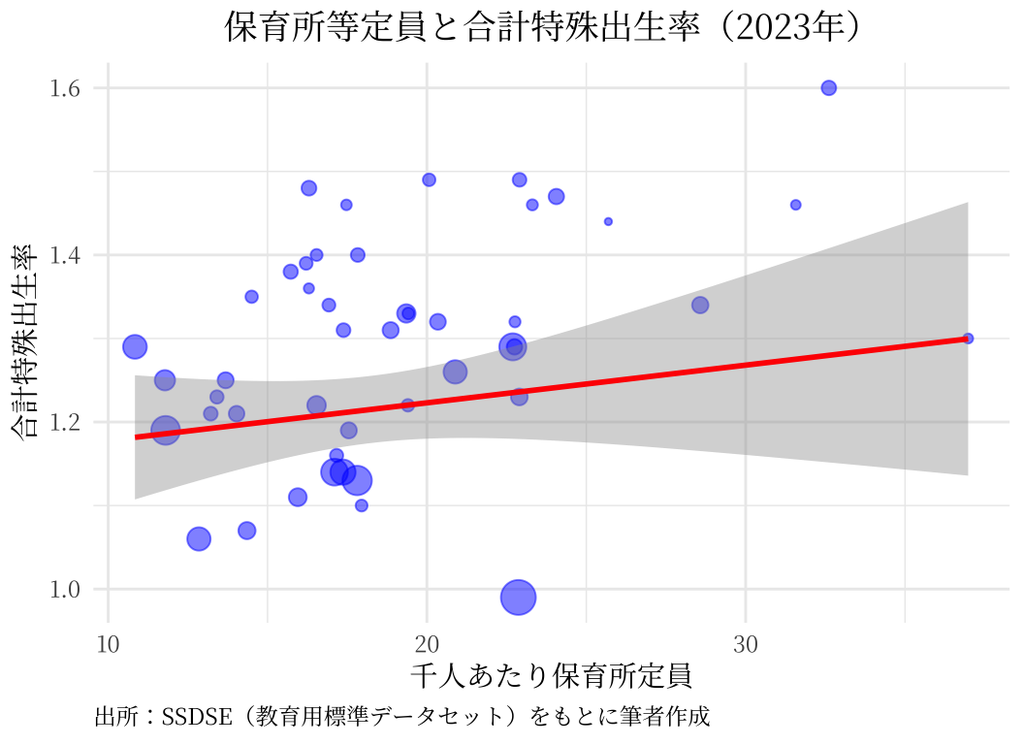

## 6.2 表を載せる：`kable()`

データフレームをそのまま出力すると、Consoleと同じ素っ気ない表示になり、そのままレポートに載せると雑な印象を与えることが多い。レポート用の整った表にするには、`knitr` パッケージの **`kable()`** に通す。`kable()` は表をHTMLの中できれいに整形してくれる関数で、列名（変数名）の付け替えや有効数字の調整もあわせて行える。

````markdown
```{r}
library(knitr)

d2023 %>%
  arrange(desc(total_fertility_rate)) %>%
  select(prefecture, total_fertility_rate, nursery_per_1000) %>%
  head(10) %>%
  kable(
    col.names = c("都道府県", "合計特殊出生率", "千人あたり保育所等定員"),
    digits = 2,
    caption = "合計特殊出生率の上位10県（2023年）"
  )
```
````

これをKnitすると、次の表が表示される。

合計特殊出生率の上位10県（2023年）

| 都道府県 | 合計特殊出生率 | 千人あたり保育所等定員 |
| --- | --- | --- |
| 沖縄県 | 1.60 | 32.61 |
| 長崎県 | 1.49 | 22.91 |
| 宮崎県 | 1.49 | 20.07 |
| 鹿児島県 | 1.48 | 16.30 |
| 熊本県 | 1.47 | 24.06 |
| 福井県 | 1.46 | 17.47 |
| 島根県 | 1.46 | 31.57 |
| 佐賀県 | 1.46 | 23.31 |
| 鳥取県 | 1.44 | 25.69 |
| 山口県 | 1.40 | 17.83 |

列名を日本語に付け替え（`col.names`）、小数点以下の桁数をそろえる（`digits`）だけで、そのまま提出できる表になる。

## 6.3 回帰結果を載せる：`modelsummary()`

第9回・第11回で使った `modelsummary` パッケージも、R Markdownと組み合わせたときに真価を発揮する。チャンクの中で実行するだけで、論文スタイルの推定結果表が文書に埋め込まれる。

````markdown
```{r}
library(modelsummary)

model1 <- lm(total_fertility_rate ~ log(nursery_per_1000), data = d2023)

model2 <- lm(total_fertility_rate ~ log(nursery_per_1000) + log(residential_land_price),
             data = d2023)

model3 <- lm(total_fertility_rate ~ log(nursery_per_1000) + log(residential_land_price) +
               log(household_consumption),
             data = d2023)

model4 <- lm(total_fertility_rate ~ log(nursery_per_1000) + log(residential_land_price) +
               log(household_consumption) + elderly_share,
             data = d2023)

model5 <- lm(total_fertility_rate ~ log(nursery_per_1000) + log(residential_land_price) +
               log(household_consumption) + elderly_share + avg_temperature,
             data = d2023)

modelsummary(
  list("モデル1" = model1, "モデル2" = model2, "モデル3" = model3,
       "モデル4" = model4, "モデル5" = model5),
  stars = TRUE,
  gof_map = c("nobs", "r.squared"),
  coef_rename = c(
    "log(nursery_per_1000)"       = "log 千人あたり保育所定員",
    "log(residential_land_price)" = "log 住宅地価",
    "log(household_consumption)"  = "log 消費支出",
    "elderly_share"               = "高齢者割合",
    "avg_temperature"             = "年平均気温"
  ),
  title = "保育所等定員と出生率の関係（2023年）"
)
```
````

これをKnitすると、次の表が表示される。

保育所等定員と出生率の関係（2023年）

|  | モデル1 | モデル2 | モデル3 | モデル4 | モデル5 |
| --- | --- | --- | --- | --- | --- |
| (Intercept) | 0.693** | 1.466*** | 8.817*** | 10.527*** | 4.735* |
|  | (0.197) | (0.344) | (2.368) | (2.479) | (2.008) |
| log 千人あたり保育所定員 | 0.206** | 0.178** | 0.177** | 0.153* | 0.043 |
|  | (0.068) | (0.064) | (0.059) | (0.059) | (0.046) |
| log 住宅地価 |  | -0.065* | -0.045+ | -0.107* | -0.154*** |
|  |  | (0.024) | (0.023) | (0.041) | (0.030) |
| log 消費支出 |  |  | -0.601** | -0.639** | -0.193 |
|  |  |  | (0.192) | (0.188) | (0.153) |
| 高齢者割合 |  |  |  | -1.573+ | -0.817 |
|  |  |  |  | (0.844) | (0.620) |
| 年平均気温 |  |  |  |  | 0.045*** |
|  |  |  |  |  | (0.007) |
| Num.Obs. | 47 | 47 | 47 | 47 | 47 |
| R2 | 0.171 | 0.286 | 0.419 | 0.463 | 0.728 |

+ p < 0.1, * p < 0.05, ** p < 0.01, *** p < 0.001

モデルを比較すると、千人あたり保育所定員の係数はかなりセンシティブで、モデルに入れる変数を変えるだけで統計的に有意でなくなることがわかる（因果推論の内容は割愛する。労働経済学IIを履修してください）。

## 6.4 Knitでよくあるエラーと対処

Knitのエラーの原因は、だいたい決まっている。次の2つの仕組みを理解しておけば、大半は自力で解決できる。

**第1に、Knitは目の前のConsoleではなく、裏で起動した別の仮想空間で実行される。** Knitしてもオブジェクトが環境欄（Environment）に現れないのは、このためである。逆に、Consoleで作ったオブジェクトや読み込んだパッケージも、Knit側からは見えない。「チャンクを▶で実行すると動くのに、Knitするとエラーになる」のは、ほぼ確実にこれが原因である。対処は1つ、**分析に必要なすべての手順（`library()`、データ読み込み、変数作成）を、`.Rmd` ファイルの中に、使う順番で書く**。データ分析の順番と同じである。

**第2に、Knit時のworking directoryは `.Rmd` ファイルの場所である。** データは `.Rmd` と同じフォルダに置き、相対パスで読み込む。`setwd()` で書き込んだ自分のPCの絶対パスは、他人のPC（採点者のPCを含む）では動かないため、提出前に削除するか、コメントアウト（行頭に `#` を付ける）しておくこと。

そのほかの典型的エラーは、次の通りである。

| 症状・エラーメッセージ | 原因 | 対処 |
| --- | --- | --- |
| `object 'd' not found` | データ読み込みがファイル内にない、または使う前のチャンクより後にある | 読み込みをsetupチャンクに書く。チャンクは上から順に実行される |
| `cannot open file '...'` | データの置き場所とパスが合っていない | データを `.Rmd` と同じフォルダに置き、相対パスで指定 |
| `Duplicate chunk label` | 同じ名前のチャンクが2つある | チャンク名（`` ```{r 名前} ``）を変えるか消す |
| Knitが終わらない・止まる | チャンクに `View()` や `install.packages()` を書いた | どちらも対話操作用なのでチャンクに書かない。`install.packages()` はConsoleで1回だけ実行 |
| 図の日本語が「□□□」になる | 日本語フォント未設定 | 実践の準備チャンクと同じ `showtext` の3行をsetupチャンクに入れる |

いずれも、エラーメッセージに**ファイル名と行番号**（例：`Quitting from lines 23-25`）が表示されるので、あわてずその行の前後を確認すればよい。

# 7 課題

今回の新しい課題はありません。第9回で出題した**データ可視化レポート**（新聞一面トップ記事、A4で1〜2ページ程度）を、今回学んだR Markdownで仕上げてください。課題テンプレート（HW7）は、下記リンクで受領してください。

HW7 https://classroom.github.com/a/fAV2BiqE

**提出物**（〆切：2026年7月25日 23:59）

1. `.Rmd` ファイル（記事の本体。分析コードを含む）
2. Knitで生成した `.html` ファイル
3. `.R` ファイル（分析コードのソース）

提出前に、**Knitが最後まで通ること**を必ず確認すること。